# DadosJus: Libertando dados do Judiciário Brasileiro

A lei de número 12.527, também conhecida como lei da transparência, foi criada em 18 de novembro de 2011. Essa lei tem como objetivo principal exigir que os órgãos integrantes da administração direta dos poderes Executivo, Legislativo, e Judiciário disponibilizem seus dados financeiros de forma pública e acessível para toda a população brasileira. Hoje todos os tribunais e ministérios públicos disponibilizam mensalmente em seus sites informações detalhada sobre seus gastos. Uma parte importante desses gastos são as remunerações dos trabalhadores e trabalhadoras desses órgãos.

Apesar dos dados estarem disponíveis ainda é difícil ter um controle social sobre os gastos de remunerações. Isso ocorre pois, os dados se encontram em diversos formatos de arquivos (.pdf, .ods, .xls, .csv, .html…) e frequentemente estão estruturados em formas diferentes, além de estarem espalhados em diversos sites e plataformas.

O DadosJus tem como objetivo realizar o processo de libertação dos dados de gastos com remunerações do poder judiciário e dos ministérios públicos do Brasil.

# Sobre os dados

As remunerações¹ incluem valores que vão além do salário². Os conhecidos auxílios ou indenizações, são gastos eventuais que podem constituir as remunerações. Auxílios como alimentação, pré escolar, saúde, natalidade, moradia e ajuda de custo, são exemplos de indenizações que podem ser recebidas por funcionários dos tribunais e ministérios públicos do Brasil

- ¹Remuneração: é a soma do salário mais outras vantagens (indenizações e auxílios).
- ²Salário: valor recebido de acordo com a prestação de serviços, em decorrência do contrato de trabalho.

# Paraíba

No estado da Paraíba temos três tribunais. São eles: Tribunal de Justiça da Paraíba (TJPB), Tribunal Regional Eleitoral da Paraíba (TRE) e Tribunal Regional do Trabalho 13º Região (TRT13). Ainda temos o Ministério Público da Paraíba (MPPB). Na nossa análise mais recente (out/2019), o TRE apresentava um total de **801**. funcionários e o no TRT13 são **1521**. No MPPB temos **1295**.

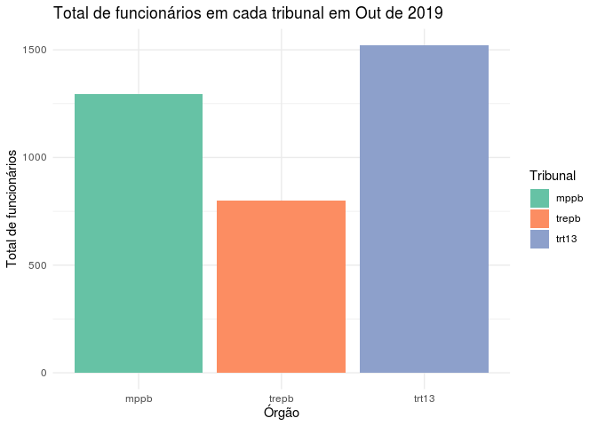

## TRT13

O TRT13 atualmente tem um total de **1521** funcionários. A remuneração mediana no ano de 2019 foi de R$ **17522.92** . Enquanto a máxima foi de R$ **370603.66** e o mínimo de R$ **0**.

No ano de 2018 tivemos uma remuneração mediana de R$ **16756.97**. Enquanto a máxima é de R$ **200845.85** e o mínimo de R$ **0**.

### Servidores são maioria no TRT13 e quantidade de pensionista e membros é quase igual

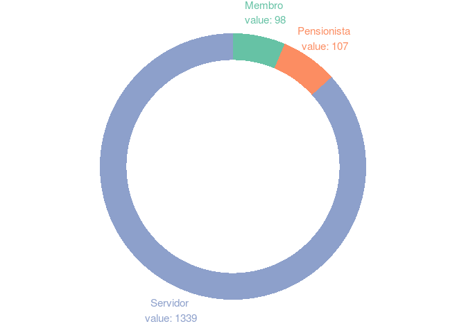

São **1339** servidores, **98** membros e **107** pensionistas.

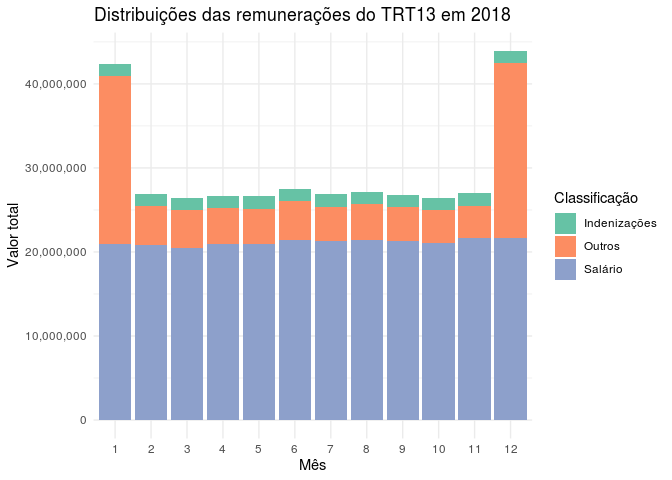

Nos meses de janeiro e dezembro o gastos com ‘outros’ são maiores ou quase iguais aos de salários.

### O Salário médio de um membro é o dobro do salário médio de um servidor

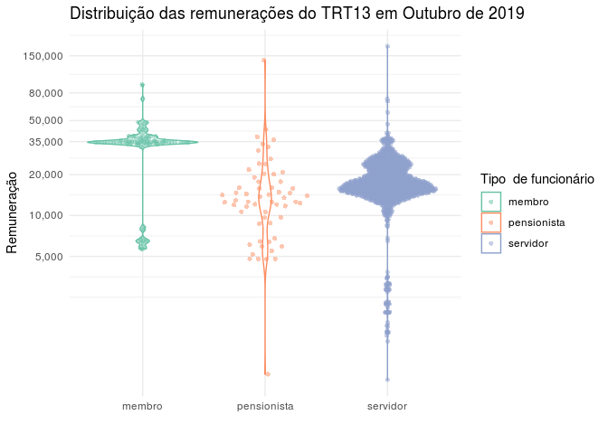

O salário mediano em 2019 para um sevidor foi de R$ **19249.6156272** . Já para membros foi de R$ **34922.1776045**. Enquanto para pensionistas é de R$ **9251.4788746**

### Analista Judiciário recebe 370.603,00 R$ em maio de 2019

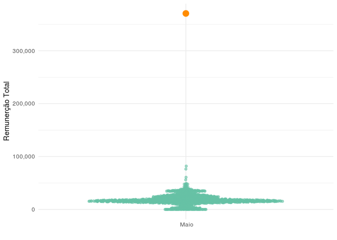

Em maio de 2019 um Analista Judiciário recebeu um total de de **370.603,00 R$**

### Distribuição das remunerações no ano de 2019

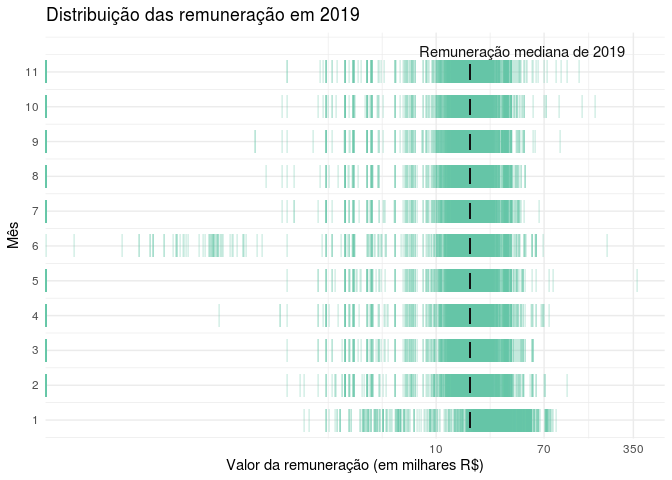

### Os Juizes tem as melhores remunerações, seguidos pelos Análistas Judiciários.

Os Juízes do TRT13 são os que apresentam as melhores remunerações no TRT13. Em segundo lugar temos os Analistas Judiciários. Em Terceiro os Técnico Judiciários. As categorias Sem Vínculo e Auxiliar Judiciário são minoria no TRT13 e apresentam as menores remunerações.

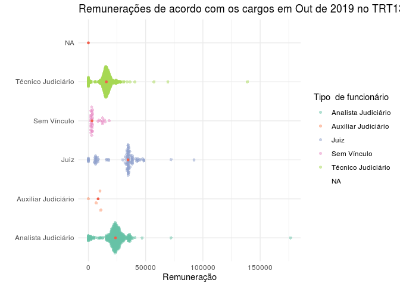

## TRE

### Gastos com ‘outros’ são maiores que os de salários em alguns meses

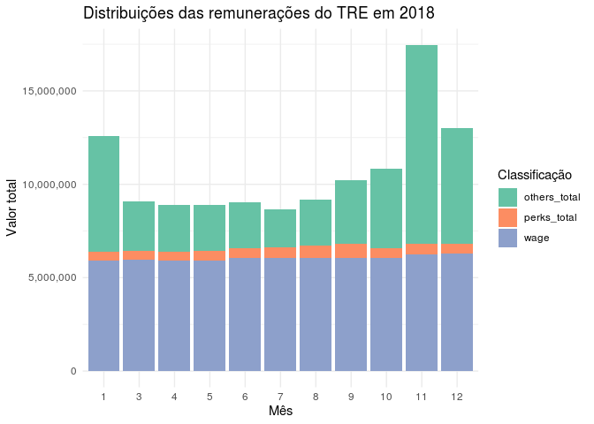

Nos meses de janeiro, novembro e dezembro o gastos com ‘outros’ são maiores ou quase iguais aos de salários.

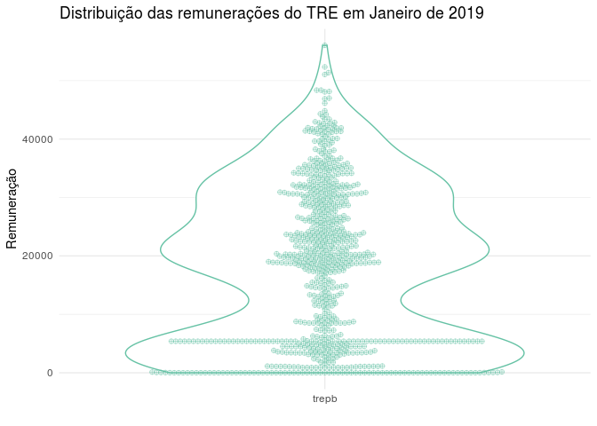

### Analistas Judiciários ganham em média 8.000,00 R$ a mais que Técnicos Judiciários

O cargo de Analista Judiciário recebe em média **23.401,00 R$**. Enquanto o Técnico Judiciário tem uma remunerção média de **15.761,00 R$**.

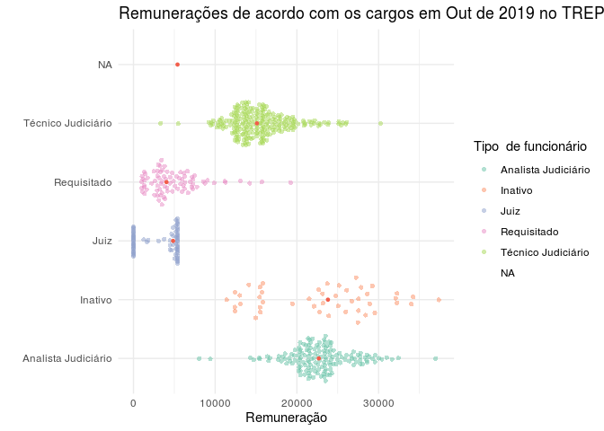

# Dúvidas

- Os pensionistas só apararecem se eu tirar o filtro de incometotal > 0 devo deixar esse filtro ou não?
- Usar o income_total ou fazendo o calculo dos descontos?
- Barras ou donut ?

[figure not shown]